# Sample size calculation in R

Yannick Vandendijck

# Systolic Blood Pressure (SBP) example

This example has been used in class and we will use it in several examples below. The framework of the experiment is to investigate the effect of a hypothetical drug on blood pressure:

1. Two samples of independent patients
2. Compare systolic blood pressure (SBP) in a treatment group and control group
3. SBP is measured using a standard sphygmomanometer
4. Treatment is expected to reduce SBP

**How many patients should we include in the control group and test group?**

We will assume the following choices:

1. Significance level to control Type I error set to 0.05 (alpha)
2. Power of 85%
3. Variance of 400 (or, standard deviation of 20)
4. Effect size (smallest effect of clinical interest) to be a reduction of 15 (Thus we think the hypothetical drug can reduce blood pressure by at least 15).

# Z-test Manually

This approach is not recommended.

Let us use the formula for the one sample Z-test:

1. `zA` quantile of standard normal distribution related to Type I error
2. `zB` quantile of standard normal distribution related to power (Type II error)
3. `sigma^2` variance of the distribution
4. `delta` effect size that we are interested to detect

In the following piece of code we define a function that calculates the sample size using the formula for the one sample Z-test:

```r
sampleSizeZtest <-  function(alpha, sigma, power, delta){
    zA <-  qnorm(p = alpha, mean = 0, sd = 1)
    zB <-  qnorm(p = power, mean = 0, sd = 1)
    sampleSize <- 2*(zA-zB)^2*(sigma^2/delta^2)
    return(round(sampleSize, 2))
}
```

For SBP example, we will have:

```r
sampleSizeZtest(alpha = 0.05, sigma = 20, power = 0.85, delta = 15)
```

```
## [1] 25.56
```

Note that we have a slightly different result than in class (26 instead of 27). The reason is that the sample size calcluation using the Z-test assumes the **variance is known**. Whereas, the result of the t-test in class assumes the variance is unknown. Hence, using the Z-test there is less information needed to be estimated, so it is expected that a smaller sample size is obtained.

# R Core Library stats

R core library `stats` is a fully reliable tool and very simple to use. However, it offers only solutions for several basic sample size calculation frameworks.

## t-test

The function `power.t.test` should be used.

```r
power.t.test(n = , delta = 15, sig.level = 0.05, sd = 20, power = 0.85, type = "two.sample",
        alternative = "one.sided")
```

```
##
##      Two-sample t test power calculation
##
##               n = 26.26614
##           delta = 15
##              sd = 20
##       sig.level = 0.05
##           power = 0.85
##     alternative = one.sided
##
## NOTE: n is number in *each* group
```

Notice that we fill in all the items except the `n` that we wish to calculate. This is the function that was used to obtain 27 patients per group for the SBP example.

We do not obtain value of 27 precisely, but 26.26614. Reasonable practice is to round the result up to next higher integer value. If we wish to know the exact power achieved with 27 patients, we can proceed with filling in `n` and leaving `power` empty:

```r
power.t.test(n = 27, delta = 15, sig.level = 0.05, sd = 20, power = NULL, type = "two.sample",
        alternative = "one.sided")
```

```
##
##      Two-sample t test power calculation
##
##               n = 27
##           delta = 15
##              sd = 20
##       sig.level = 0.05
##           power = 0.8587416
##     alternative = one.sided
##
## NOTE: n is number in *each* group
```

We reach a power of almost 86% with 27 patients per group.

In case you do a **two-sided test** you can add a parameter `strict`. If strict = TRUE is used, the power will include the probability of rejection in the opposite direction of the true effect, in the two-sided case. Without this the power will be half the significance level if the true difference is zero. For details, refer to help of the function:

```r
?power.t.test
```

*Note:* in most practical cases the difference between strict = TRUE or strict = FALSE is very small (negligible).

```r
power.t.test(n = , delta = 15.0, sig.level = 0.05, sd = 20, power = 0.80, type = "two.sample",
             alternative = "two.sided", strict=FALSE)
```

```
##
##      Two-sample t test power calculation
##
##               n = 28.89962
##           delta = 15
##              sd = 20
##       sig.level = 0.05
##           power = 0.8
##     alternative = two.sided
##
## NOTE: n is number in *each* group
```

```r
power.t.test(n = , delta = 15.0, sig.level = 0.05, sd = 20, power = 0.80, type = "two.sample",
             alternative = "two.sided", strict=TRUE)
```

```
##
##      Two-sample t test power calculation
##
##               n = 28.89955
##           delta = 15
##              sd = 20
##       sig.level = 0.05
##           power = 0.8
##     alternative = two.sided
##
## NOTE: n is number in *each* group
```

## Proportion test

In case of a comparison of two proportions (i.e. probabilties of success of two binary distributions) not only the difference between the proportions $\pi_1$ and $\pi_2$ is important, but also the actual proportions are important. This is due to the dependence between mean and variance of the binary distribution (variance: $\pi_1(1-\pi_1)+\pi_2(1-\pi_2)$).

Therefore, although the absolute value of the difference of the probabilities is 0.3, in the following examples, we obtain different sample sizes:

```r
power.prop.test(n = NULL, p1 = 0.1, p2 = 0.4, sig.level = 0.05, power = 0.80)
```

```
##
##      Two-sample comparison of proportions power calculation
##
##               n = 31.49838
##              p1 = 0.1
##              p2 = 0.4
##       sig.level = 0.05
##           power = 0.8
##     alternative = two.sided
##
## NOTE: n is number in *each* group
```

```r
power.prop.test(n = NULL, p1 = 0.5, p2 = 0.8, sig.level = 0.05, power = 0.80)
```

```
##
##      Two-sample comparison of proportions power calculation
##
##               n = 38.48004
##              p1 = 0.5
##              p2 = 0.8
##       sig.level = 0.05
##           power = 0.8
##     alternative = two.sided
##
## NOTE: n is number in *each* group
```

*Note:* Since there is symmetry around $p=0.5$ we have the same sample size in the following example:

```r
power.prop.test(n = NULL, p1 = 0.1, p2 = 0.4, sig.level = 0.05, power = 0.90, alternative = "one.sided")
```

```
##
##      Two-sample comparison of proportions power calculation
##
##               n = 33.77386
##              p1 = 0.1
##              p2 = 0.4
##       sig.level = 0.05
##           power = 0.9
##     alternative = one.sided
##
## NOTE: n is number in *each* group
```

```r
power.prop.test(n = NULL, p1 = 0.6, p2 = 0.9, sig.level = 0.05, power = 0.90, alternative = "one.sided")
```

```
##
##      Two-sample comparison of proportions power calculation
##
##               n = 33.77386
##              p1 = 0.6
##              p2 = 0.9
##       sig.level = 0.05
##           power = 0.9
##     alternative = one.sided
##
## NOTE: n is number in *each* group
```

Indeed, the variance in both examples is equal: $0.1\cdot (1-0.1)+0.4 \cdot(1-0.4)=0.33= 0.9\cdot (1-0.9)+0.6\cdot (1-0.6)$

## ANOVA data

In an ANOVA analysis, the following input parameters are needed:

1. Number of groups: important for the correct specification of the F-distribution degrees of freedom
2. Between-variability: parameter determined by assumed effect size
3. Within-variability: nuisance parameter

For example, if we would have 5 groups:

```r
power.anova.test(groups = 5, n = NULL, between.var = 1, within.var = 5, sig.level = 0.05, power = 0.90)
```

```
##
##      Balanced one-way analysis of variance power calculation
##
##          groups = 5
##               n = 20.23026
##     between.var = 1
##      within.var = 5
##       sig.level = 0.05
##           power = 0.9
##
## NOTE: n is number in each group
```

The between-variability does not only depend on maximal difference in the group means, but also on the actual group means. For example, we will achieve different results for the following group means specification (effect sizes):

```r
power.anova.test(groups = 5, n = NULL, between.var = var(c(10, 10, 10, 12, 12)), within.var = 5, sig.level = 0.05, power = 0.90)
```

```
##
##      Balanced one-way analysis of variance power calculation
##
##          groups = 5
##               n = 17.02569
##     between.var = 1.2
##      within.var = 5
##       sig.level = 0.05
##           power = 0.9
##
## NOTE: n is number in each group
```

```r
power.anova.test(groups = 5, n = NULL, between.var = var(c(10, 10, 10, 10, 12)), within.var = 5, sig.level = 0.05, power = 0.90)
```

```
##
##      Balanced one-way analysis of variance power calculation
##
##          groups = 5
##               n = 25.03941
##     between.var = 0.8
##      within.var = 5
##       sig.level = 0.05
##           power = 0.9
##
## NOTE: n is number in each group
```

The difference in sample size needed per group is quite high (an increase of 47%). Although, the maximal difference in the group means is the same in both case, namely $12 - 10 = 2$. However, the between-variability is different $Var(10, 12, 10, 10, 12) = 1.2$ and $Var(10, 10, 10, 10, 12) = 0.8$.

In practice, a reasonable approach would be to clearly identify the possible settings of interest and then run several sample size calculations across all of the settings. Then, selecting the maximum sample size is a conservative and recommended approach in case of no prior information.

*Note*: If you don’t know the group means but only the maximal group difference, a conservative approach is to choose a configuration of the group means that yields the smallest between-variability:

```r
var(c(10, 11, 11, 11, 12))
```

```
## [1] 0.5
```

which yields:

```r
power.anova.test(groups = 5, n = NULL, between.var = var(c(10, 11, 11, 11, 12)), within.var = 5, sig.level = 0.05, power = 0.90)
```

```
##
##      Balanced one-way analysis of variance power calculation
##
##          groups = 5
##               n = 39.47418
##     between.var = 0.5
##      within.var = 5
##       sig.level = 0.05
##           power = 0.9
##
## NOTE: n is number in each group
```

Let us see what happens if we would use the smallest sample size from the example above (n = 18) when the means would be equal (10, 11, 11, 11, 12):

```r
power.anova.test(groups = 5, n = 18, between.var = var(c(10, 11, 11, 11, 12)), within.var = 5, sig.level = 0.05, power = NULL)
```

```
##
##      Balanced one-way analysis of variance power calculation
##
##          groups = 5
##               n = 18
##     between.var = 0.5
##      within.var = 5
##       sig.level = 0.05
##           power = 0.5272467
##
## NOTE: n is number in each group
```

The power of in this setting is actually only about 53% instead of 90%. This is a huge difference.

# Specialized Libraries

For more advanced situations, specialized libraries need to be used. There are many options in **R** regarding sample size calculations. Some of them are more general, while others are field and context specific. In general, caution is needed while using third party libraries and detailed examination of manual, examples, vignettes and codes is recommended.

## MESS Library

I don’t know the details of this library. However, this package has a function to calculate the power and sample size for the two-sample t-test with unequal sample size in each group. This could be useful if we want to sample treated:placebo patients with a ratio of 3:1, for example.

If the sample size would be equal in both groups (1:1) specified with ratio=1 we get similar results as above. Thus a total sample size of $27 + 27 = 54$.

```r
power_t_test(n = , delta = 15, sig.level = 0.05, sd = 20, power = 0.85, type = "two.sample",
        alternative = "one.sided", ratio = 1)
```

```
##
##      Two-sample t test power calculation
##
##               n = 26.26614
##           delta = 15
##              sd = 20
##       sig.level = 0.05
##           power = 0.85
##     alternative = one.sided
##
## NOTE: n is number in *each* group
```

However, sampling in a ratio of 3:1 (specified with ratio=3) yields:

```r
power_t_test(n = , delta = 15, sig.level = 0.05, sd = 20, power = 0.85, type = "two.sample",
        alternative = "one.sided", ratio = 3)
```

```
##
##      Two-sample t test power calculation with unequal sample sizes
##
##               n = 17.878, 53.634
##           delta = 15
##              sd = 20, 20
##       sig.level = 0.05
##           power = 0.85
##     alternative = one.sided
##
## NOTE: n is vector of number in each group
```

Thus a total sample size of $18 + 54 = 72$.

# Simulations

This **one size fits all** approach can be used in all scenarios. However, it is the most time consuming solution and requires notions of programming.

1 Two-sample t-test

2 Comparison of Poisson distributed data

**Note:** With simulation the result depends on the `seed` specified. Hence, it is important to track the seed and note that changing the seed may have a small influence on reported result when the number of simulation is large enough.

## Example 1: t-test

Let us start with the example of a two-sample t-test to demonstrate the essential principles of the simulation approach to perform sample size calculation. In summary the following steps are done:

1 Set a sample size

2 Fix the other input parameters: alpha, sd, effect size

3 Simulate a large number of datasets with specified sample size and input parameters

4 Calculate the power based on the choices we have made

**(1)** First, let us choose the sample size. It can be a completely random choice in the beginning. Based on the results we obtain, $N$ can be updated and iterate again.

```r
#  1. Choose sample size N per group
N = 10
```

**(2)** We have to choose the significance level, effect size and nuisance parameters (i.e., variance in this case). Unlike in step (1), all these inputs have to be informative choices:

```r
# 2. Fix other parameters
alpha = 0.05
delta = 15       # effect size
sdChoice = 20    # standard deviation in the population
```

**(3)** The core part of the simulation approach is the generation of a large number of data sets with sample size $N$ from the assumed distributions with exactly the specified effect size and variance. As you want to calculate the power P(H1|H1), you simulate data under the alternative hypothesis H1. After that we perform the statistical test and save the p-values.

```r
# 3. Simulate large number of experiments
numberSimulation <- 5000
pval <- numeric(numberSimulation) # here we will store the p-values of 1000 tests that are performed

set.seed(1234) # set the seed for reproducible results - very important
for (i in 1:numberSimulation){
    # we set any mean we wish, it does not matter. only difference delta is important
  # [this holds for this particular setting of normal distribution and t-test, possibly not the case in other scenarios]
  # we simulate data from the normal distribution (assumption t-test)
    controlGroup <- rnorm(N, mean = 120, sd = sdChoice)
    treatedGroup <- rnorm(N, mean = 120 - delta, sd = sdChoice)   # here we have the delta
    # we perform the one-sided t-test on the data and save the p-value
    pval[i] <- t.test(controlGroup, treatedGroup, alternative = "greater",
            mu = 0, paired = FALSE, var.equal = TRUE, conf.level = 1-alpha)$p.value
}

head(pval) # will print the first 6 p-values (as you can see 3 out of these 6 are smaller than 0.05 and thus reject H0)
```

```
## [1] 0.153647649 0.002482146 0.182087743 0.003601356 0.468831425 0.015524328
```

**(4)** Finally, we check in how many simulated data sets the null hypothesis has been rejected (p-value < alpha). The proportion of rejected null hypothesis is the approximate power of the test under the given fixed parameters and the sample size N.We can estimate the power for the given setting:

```r
# 4. Estimate power
# power translates to: how often we reject H0 if the true effect is delta; power=P(H1|H1)
# (given significance level alpha = 0.05)
sum(pval < alpha)/numberSimulation
```

```
## [1] 0.4934
```

In this case, the estimated power is about $49\%$ which is clearly not sufficient. Recall that our target power has been $85\%$. This implies the initial sample size of $N=10$ is not large enough for this particular case. Therefore, we would need to increase `N` in first step and run the whole procedure again. We repeat the procedure and adjust the sample size until the desired power is achieved.

*Exercise:* repeat this exercise for N=27.

### For-loop over sample sizes

The whole approach of updating the sample size can be automated. You simply run your code over a loop of possible `N` values:

```r
Nvec <- seq(15, 35, by = 1) # here we specify the possible sample size N we want to investigate
numberSimulation <- 10000
pval <- numeric(numberSimulation)

sampleSizePower <- numeric(length(Nvec))
names(sampleSizePower) <- Nvec

set.seed(1234)

for (j in 1:length(Nvec)){
    for (i in 1:numberSimulation){
        controlGroup <- rnorm(Nvec[j], mean = 120, sd = sdChoice)
        treatedGroup <- rnorm(Nvec[j], mean = 120 - delta, sd = sdChoice)
        pval[i] <- t.test(controlGroup, treatedGroup, alternative = "greater",
                mu = 0, paired = FALSE, var.equal = FALSE, conf.level = 0.95)$p.value
    }
    sampleSizePower[j] <- sum(pval < alpha)/numberSimulation
}
# power for all sample sizes between 15 and 30
sampleSizePower
```

```
##     15     16     17     18     19     20     21     22     23     24     25
## 0.6380 0.6655 0.6840 0.7037 0.7284 0.7570 0.7735 0.7862 0.8030 0.8218 0.8316
##     26     27     28     29     30     31     32     33     34     35
## 0.8431 0.8580 0.8733 0.8780 0.8919 0.8958 0.9064 0.9129 0.9216 0.9274
```

```r
# for which sample size we have a power of at least 85%
sampleSizePower[which(sampleSizePower > 0.85)]
```

```
##     27     28     29     30     31     32     33     34     35
## 0.8580 0.8733 0.8780 0.8919 0.8958 0.9064 0.9129 0.9216 0.9274
```

The result suggests that we should use 27 observations per group. As expected, the result corresponds to the results of the function from the `stats` library.

```r
power.t.test(n = , delta = 15, sig.level = 0.05, sd = 20, power = 0.85, type = "two.sample",
        alternative = "one.sided")
```

```
##
##      Two-sample t test power calculation
##
##               n = 26.26614
##           delta = 15
##              sd = 20
##       sig.level = 0.05
##           power = 0.85
##     alternative = one.sided
##
## NOTE: n is number in *each* group
```

We can also plot the results from the simulation study:

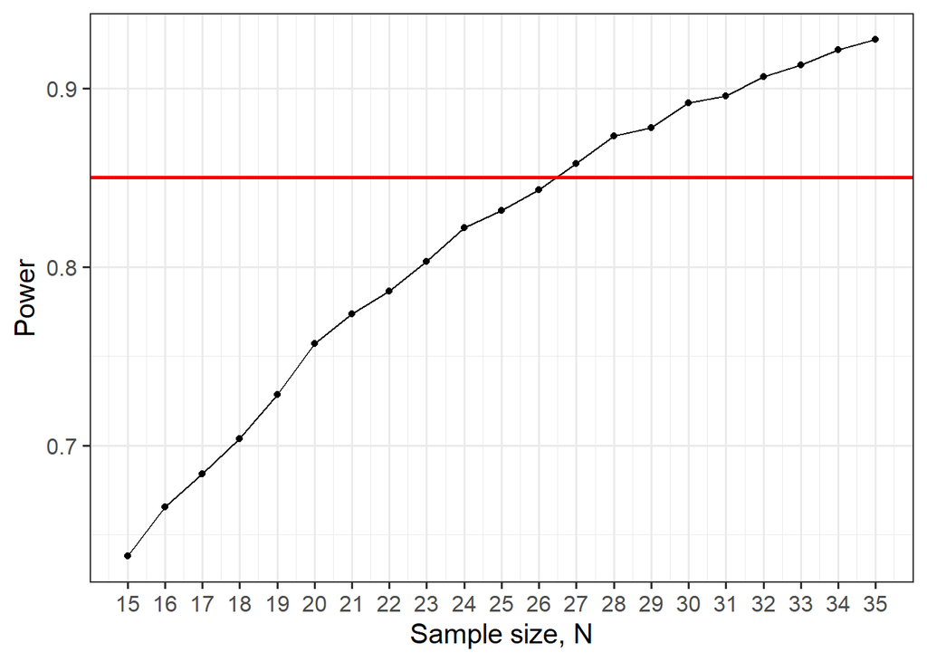

```r
plot.data = data.frame(x=Nvec, y=sampleSizePower)
ggplot(data=plot.data, aes(x=x, y=y)) +
  theme_bw(base_size=15) +
  geom_point() +
  geom_line() +
  labs(x="Sample size, N", y="Power") +
  geom_hline(yintercept=0.85, linetype=1, col="red", size=1) +
  scale_x_continuous(breaks = Nvec)
```

## Example 2: Poisson data

Poisson data poses a challenge in sample size calculation since the variance and mean are equal. Hence, pilot data knowledge on the variance immediately implies knowledge on the effect size. For Poisson data, there are some functions available in the libraries `Sequential` and `asypow`:

```r
?SampleSize.Poisson
?asypow.n
```

However, the simulation approach can be applied generally and offers a very efficient solution for Poisson data.

We are interested in comparing a Poission distributed outcome in two groups. This translates into the Poisson case of a two sample t-test. We assume the parameters in the two groups can be denoted as $\lambda_1$ and $\lambda_2$. We are thus interested in testing the following hypothesis:

$H_0: \lambda_1 = \lambda_2$ versus $H_1: \lambda_1 \neq \lambda_2$.

*Important:* using the standard two-sample t-test is less valid since the observations will be Poisson distributed and not normal.

Again, We start with a random choice of the sample size `N`. Although we are primarily interested in the difference between $\lambda_1$ and $\lambda_2$, we need to specify the actual values of two means. This is needed since the mean = variance in the Poisson distribution.

A possible option is to run a small/medium sized pilot experiment on the control group to get a reasonable estimate of $\lambda_1$ in the control group. Then for the treated group $\lambda_2$ can be specified according to the desired effect size (i.e. treatment effect), $\lambda_2 = \lambda_1 + \Delta$.

```r
# 1. Choose sample size per group
N <- 200

# 2. Select parameters
lambda.control = 7   # e.g. this value may come from pilot experiment or historical knowledge (lambda1)
lambda.treated = 6.3 # i.e. we are interested in reduction of the control mean by 0.7 or a relative decrease of 10% (lambda 2)
alpha = 0.05  # significance level

# 3. Simulate huge number of experiments and test
numberSimulation <- 10000
pval <- numeric(numberSimulation)

set.seed(1234) # set the seed for reproducible results
for (i in 1:numberSimulation){
  # we simulate from Poisson distribution
  controlGroup <- rpois(N, lambda = lambda.control)
  treatedGroup <- rpois(N, lambda = lambda.treated)
  simData <- data.frame(response = c(controlGroup, treatedGroup), treatment = rep(c(0, 1), each = N))
  # we use a GLM model for Poisson regression to test effect of treatment
  pval[i] <- summary(glm(response ~ treatment, data = simData, family=poisson()))$coeff["treatment", "Pr(>|z|)"]
}

# 4. Estimate power
sum(pval < alpha)/numberSimulation
```

```
## [1] 0.7789
```

We achieve a power of about $78\%$ in this case. If we would require a higer power, we need to increase `N`.